# Project 7: Difference-in-Differences and Synthetic Control

```r
# Install and load packages
#if (!require("pacman")) install.packages("pacman")

#devtools::install_github("ebenmichael/augsynth")

library(pacman)
library(augsynth)
pacman::p_load(# Tidyverse packages including dplyr and ggplot2
               tidyverse,
               ggthemes,
               #augsynth,
               gsynth,
               scales)
```

# Introduction

For this project, you will explore the question of whether the Affordable Care Act increased health insurance coverage (or conversely, decreased the number of people who are uninsured). The ACA was passed in March 2010, but several of its provisions were phased in over a few years. The ACA instituted the “individual mandate” which required that all Americans must carry health insurance, or else suffer a tax penalty. There are four mechanisms for how the ACA aims to reduce the uninsured population:

- Require companies with more than 50 employees to provide health insurance.
- Build state-run healthcare markets (“exchanges”) for individuals to purchase health insurance.
- Provide subsidies to middle income individuals and families who do not qualify for employer based coverage.
- Expand Medicaid to require that states grant eligibility to all citizens and legal residents earning up to 138% of the federal poverty line. The federal government would initially pay 100% of the costs of this expansion, and over a period of 5 years the burden would shift so the federal government would pay 90% and the states would pay 10%.

In 2012, the Supreme Court heard the landmark case NFIB v. Sebelius, which principally challenged the constitutionality of the law under the theory that Congress could not institute an individual mandate. The Supreme Court ultimately upheld the individual mandate under Congress’s taxation power, but struck down the requirement that states must expand Medicaid as impermissible subordination of the states to the federal government. Subsequently, several states refused to expand Medicaid when the program began on January 1, 2014. This refusal created the “Medicaid coverage gap” where there are indivudals who earn too much to qualify for Medicaid under the old standards, but too little to qualify for the ACA subsidies targeted at middle-income individuals.

States that refused to expand Medicaid principally cited the cost as the primary factor. Critics pointed out however, that the decision not to expand primarily broke down along partisan lines. In the years since the initial expansion, several states have opted into the program, either because of a change in the governing party, or because voters directly approved expansion via a ballot initiative.

You will explore the question of whether Medicaid expansion reduced the uninsured population in the U.S. in the 7 years since it went into effect. To address this question, you will use difference-in-differences estimation, and synthetic control.

# Data

The dataset you will work with has been assembled from a few different sources about Medicaid. The key variables are:

- **State**: Full name of state
- **Medicaid Expansion Adoption**: Date that the state adopted the Medicaid expansion, if it did so.
- **Year**: Year of observation.
- **Uninsured rate**: State uninsured rate in that year.

# Exploratory Data Analysis

Create plots and provide 1-2 sentence analyses to answer the following questions:

- Which states had the highest uninsured rates prior to 2014? The lowest?
- Which states were home to most uninsured Americans prior to 2014? How about in the last year in the data set? **Note**: 2010 state population is provided as a variable to answer this question. In an actual study you would likely use population estimates over time, but to simplify you can assume these numbers stay about the same.

```r
# set seed
set.seed(31)

# load data
medicaid_expansion <- read_csv("/home/otis/Downloads/medicaid_expansion.csv")
```

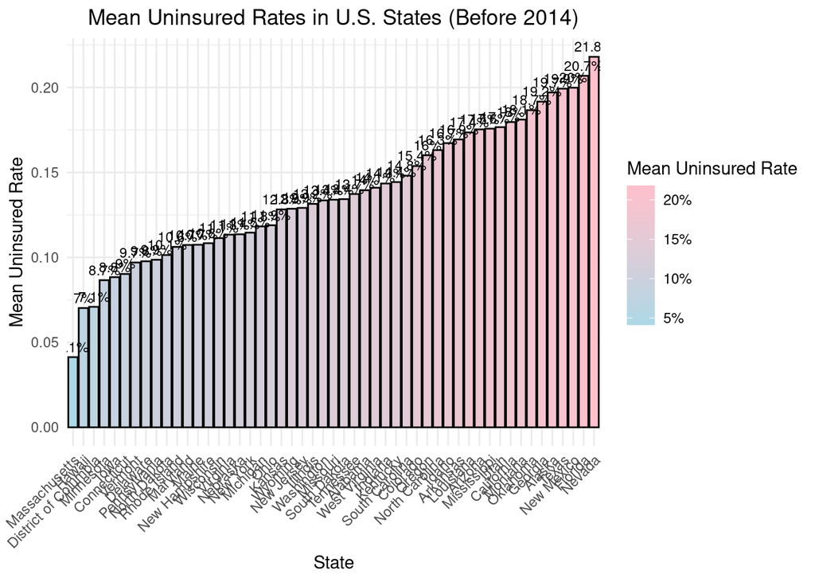

```r
# highest and lowest uninsured rates

library(dplyr)
library(ggplot2)
library(scales)  # For percent_format

# Filter data for years before 2014
medicaid_expansion_filtered <- medicaid_expansion %>%
  filter(year < 2014)

# Calculate mean uninsured rate by state
uninsured_rates <- medicaid_expansion_filtered %>%
  group_by(State) %>%
  summarize(mean_uninsured_rate = mean(uninsured_rate, na.rm = TRUE))

# Plot
ggplot(data = uninsured_rates, aes(x = reorder(State, mean_uninsured_rate), y = mean_uninsured_rate, fill = mean_uninsured_rate)) +
  geom_bar(stat = "identity", color = "black") +
  scale_fill_gradient(low = "lightblue", high = "pink", name = "Mean Uninsured Rate", labels = percent_format()) +  # Use gradient color scheme and include legend
  theme_minimal() +
  theme(axis.text.x = element_text(angle = 45, hjust = 1)) +
  ggtitle("Mean Uninsured Rates in U.S. States (Before 2014)") +
  xlab("State") +
  ylab("Mean Uninsured Rate") +
  geom_text(aes(label = paste0(round(mean_uninsured_rate * 100, 1), "%")), vjust = -0.5, size = 3) +  # Add data labels
  theme(plot.title = element_text(hjust = 0.5))  # Center title
```

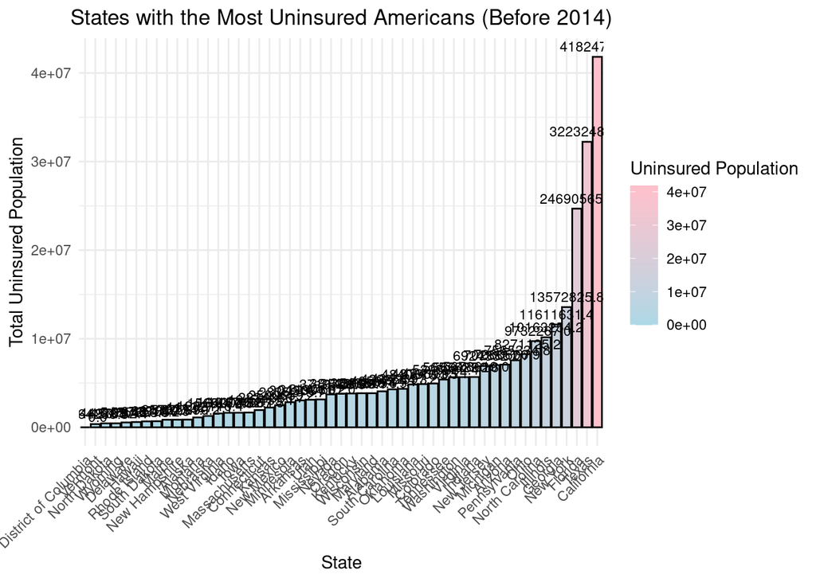

```r
# most uninsured Americans

# Calculate uninsured population by state
medicaid_expansion <- medicaid_expansion %>%
  mutate(uninsured_pop = uninsured_rate * population)

# Filter data for years before 2014
medicaid_expansion_filtered <- medicaid_expansion %>%
  filter(year < 2014)

# Summarize uninsured population by state
uninsured_pop_by_state <- medicaid_expansion_filtered %>%
  group_by(State) %>%
  summarize(uninsured_pop = sum(uninsured_pop, na.rm = TRUE))  # Calculate total uninsured population

# Plot
ggplot(data = uninsured_pop_by_state, aes(x = reorder(State, uninsured_pop), y = uninsured_pop, fill = uninsured_pop)) +
  geom_bar(stat = "identity", color = "black") +
  scale_fill_gradient(low = "lightblue", high = "pink", name = "Uninsured Population") +  # Use gradient color scheme
  theme_minimal() +
  theme(axis.text.x = element_text(angle = 45, hjust = 1)) +
  ggtitle("States with the Most Uninsured Americans (Before 2014)") +
  xlab("State") +
  ylab("Total Uninsured Population") +
  geom_text(aes(label = format(uninsured_pop, scientific = FALSE)), vjust = -0.5, size = 3) +  # Add data labels
  theme(plot.title = element_text(hjust = 0.5))  # Center title
```

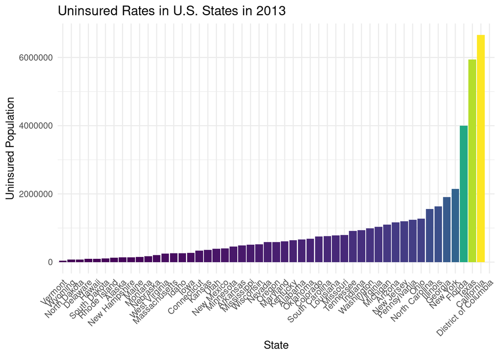

```r
# Load necessary packages
library(dplyr)
library(ggplot2)

# Filter data for the year 2013
medicaid_expansion_2013 <- medicaid_expansion %>%
  filter(year == 2013)

# Summarize data by state
state_summary <- medicaid_expansion_2013 %>%
  group_by(State) %>%
  summarize(uninsured_pop = mean(uninsured_pop, na.rm = TRUE))

# Create gradient color palette
color_palette <- scales::viridis_pal()(length(unique(state_summary$uninsured_pop)))

# Create bar plot with gradient colors
ggplot(state_summary, aes(x = reorder(State, uninsured_pop), y = uninsured_pop, fill = uninsured_pop)) +
  geom_bar(stat = "identity") +
  scale_fill_gradientn(colors = color_palette) +  # Gradient color scale
  theme_minimal() +
  theme(axis.text.x = element_text(angle = 45, hjust = 1)) +
  ggtitle("Uninsured Rates in U.S. States in 2013") +
  xlab("State") +
  ylab("Uninsured Population") +
  scale_y_continuous(labels = function(x) format(x, scientific = FALSE)) +
  guides(fill = FALSE)  # Hide the fill legend for a cleaner look
```